# MATH464/564: Practical 2a: Directed acyclic graphs and confounding

Tom Palmer

19/20

# Question 1

In the following DAG:

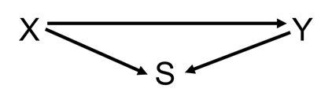

It was noticed that controlling for $S$ in the model leads to a substantial change in the estimated association between $X$ and $Y$. Should we condition on $S$? Give your reasons.

We don’t want to adjust for $S$ because it is a collider.

# Question 2

In this question we are attempting to estimate the effect of $X$ on $Y$.

1. Write down the (old) definition of a confounder

A confounder should be:

- associated with the exposure
- associated with the outcome conditional upon the exposure
- not on the causal pathway between the exposure and outcome
2. Write down Pearl’s definition of a confounder

A confounder is any variable on a backdoor pathway between an exposure and an outcome.

3. For each of the following DAGs assess whether $L$ is confounder using both the old and new definitions.

DAG A

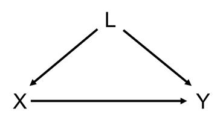

$L$ is a confounder under both definitions.

DAG B

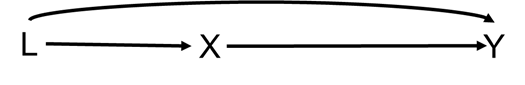

$L$ is a confounder under both definitions.

DAG C

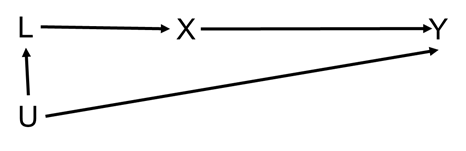

$L$ is a confounder under both definitions.

DAG D

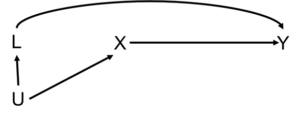

$L$ is a confounder under both definitions.

DAG E

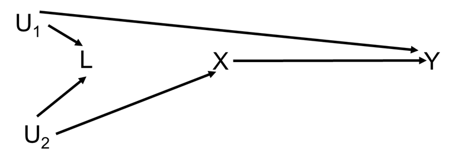

Under the old definition $L$ is a confounder because $L$ is associated with the exposure $X$ ($L$-$U_2$-$X$ is an open path) and it is associated with the outcome conditional upon the exposure ($L$-$U_1$-$Y$ is an open path).

Under our structural rules $L$ is a collider of $U_1$ and $U_2$. Hence including $L$ in a model will open the path between $U_1$ and $U_2$ which would bias the association between $X$ and $Y$. Hence, under the *d*-separation rules we don’t want to adjust for $L$, even though we consider it a confounder under the old rules.

The lesson here is that the old definition breaks down for complex models, especially when there is a collider on a backdoor pathway.

# Question 3

The fetal origins hypothesis suggests that there are associations between prenatal growth and adult heart disease.

Huxley et al., Unravelling the fetal origins hypothesis: is there really an inverse association between birthweight and subsequent blood pressure? Lancet, 2002, 360, 9334, 659–665, https://doi.org/10.1016/S0140-6736(02)09834-3, reviewed 55 studies that reported associations between birthweight, the exposure, and later life systolic blood pressure, the outcome. The table below shows what potential confounding factors the authors adjusted for.

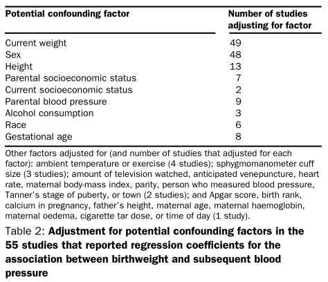

As you can see the vast majority of these associations were adjusted for current weight. In the Results section the authors commented as follows.

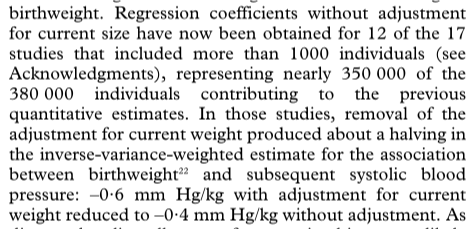

So, removing the adjustment for current weight, in 12 studies, halved the magnitude of the pooled association. The pooled association with adjustment was -0.6 mmHg/kg; and without adjustment was -0.4 mmHg/kg.

Draw a possible DAG for the relationship between birthweight, current weight, and current SBP.

Current weight could be a mediator of the association between birthweight and current SBP.

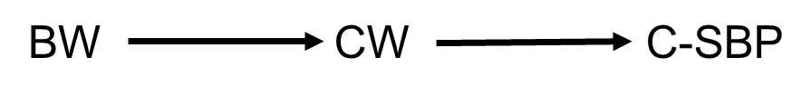

# Question 4

The following DAG describes a model between an exposure ($E$), a disease outcome ($D$), and three other variables ($A$, $B$, and $C$).

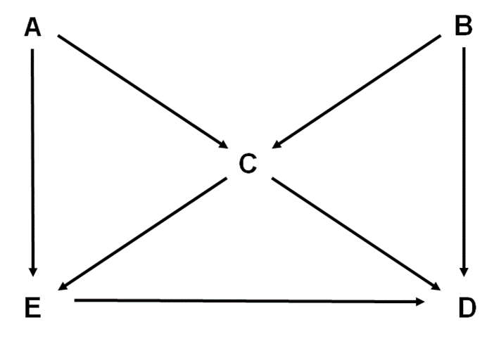

1. List all the backdoor paths between $E$ and $D$.
- E-C-D
- E-C-B-D
- E-A-C-D
- E-A-C-B-D
2. With respect to $A$ and $B$ how would you describe $C$?

With respect to $A$ and $B$, $C$ is a collider.

3. If we fitted a regression model using $B$ as the outcome regressed on covariates $A$ and $C$, what could be the problem?

Since C is a collider between A and B, fitting such a model would be biased due to adjustment for a collider.

4. Suppose we want to estimate the effect of $E$ on $D$, is there one best model to fit to estimate this association? Write down this best model/s.

There are several models which block all potential backdoor pathways. These are:

- Adjusting for C and A
- Adjusting for C and B
- Adjusting for C and A and B

Essentially given we must include in C we must then include one or both of A and B to block the A-B which opened by adjusting for C.

5. Verify your answers using the dagitty package in R.

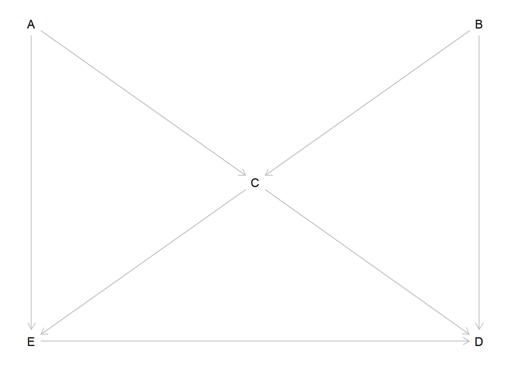

```r
#install.packages("dagitty")
library(dagitty)

g <- dagitty('dag {
  E <- A -> C <- B -> D
  E -> D
  C -> E
  C -> D
  E [exposure, pos="0,2"]
  D [outcome, pos="2,2"]
  A [pos="0,0"]
  B [pos="2,0"]
  C [pos="1,1"]
}')
plot(g)
```

```r
paths(g, "E", "D")
```

```
## $paths
## [1] "E -> D"                "E <- A -> C -> D"      "E <- A -> C <- B -> D"
## [4] "E <- C -> D"           "E <- C <- B -> D"
##
## $open
## [1]  TRUE  TRUE FALSE  TRUE  TRUE
```

Which paths remain open when conditioning on C.

```r
paths(g, "E", "D", c("C"))
```

```
## $paths
## [1] "E -> D"                "E <- A -> C -> D"      "E <- A -> C <- B -> D"
## [4] "E <- C -> D"           "E <- C <- B -> D"
##
## $open
## [1]  TRUE FALSE  TRUE FALSE FALSE
```

```r
impliedConditionalIndependencies(g)
```

```
## A _||_ B
## A _||_ D | B, C, E
## B _||_ E | A, C
```

What do we need to adjust for to estimate the effect of E on D?

```r
adjustmentSets(g)
```

```
##  { B, C }
##  { A, C }
```

## M-bias applied example

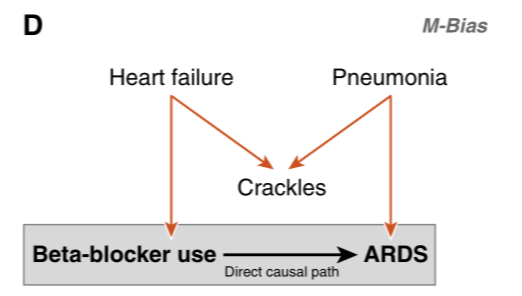

The orange arrows represent a closed back-door path: chronic beta-blocker therapy $\leftarrow$ heart failure $\rightarrow$ Crackles $\leftarrow$ Pneumonia $\rightarrow$ acute respiratory distress syndrome (ARDS).

Crackles stands for auscultatory crackles: https://en.wikipedia.org/wiki/Crackles

Crackles is a collider that naturally leaves the back-door path closed. However, control for crackles would open the back-door path, introducing confounding through the path (beta-blocker – heart failure – pneumonia – ARDS).

M-bias: bias induced by a backdoor path which includes a collider.

We can modify the DAG to show that we don’t need to adjust under an M structure.

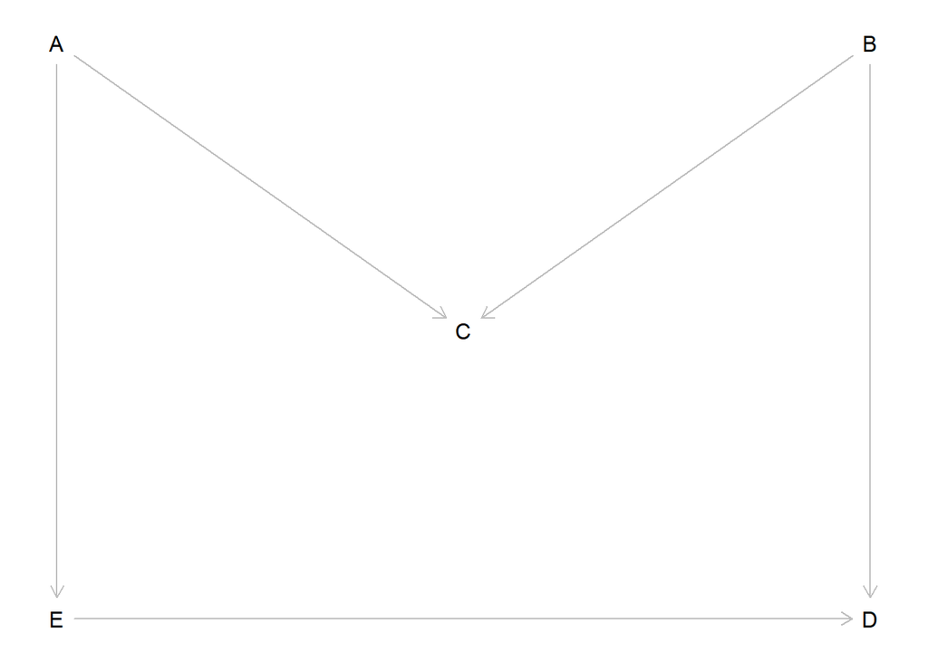

```r
g2 <- dagitty('dag {
  E <- A -> C <- B -> D
  E -> D
  E [exposure, pos="0,2"]
  D [outcome, pos="2,2"]
  A [pos="0,0"]
  B [pos="2,0"]
  C [pos="1,1"]
}')
plot(g2)
```

```r
adjustmentSets(g2)
```

```
##  {}
```

The adjustment set is the empty set, i.e. don’t adjust for any covariates.